# Replicating Walker et al. (2023) with IPEDS Data

Anticipatory impacts of the repeal of Roe v. Wade on female college applicants

# Introduction

- Walker, Wisniewski, Torres, and Sharma (2023), *Economics Letters*
  - Examine *anticipatory* impacts of restrictive abortion policy on applications to top U.S. colleges.
  - Use the Common Data Set and U.S. News & World Report rankings.
  - Assume the overturning of federal protections in *Roe v. Wade* was anticipated.
  - Find a decrease in the share of women applicants.
- Replicate with IPEDS data using a slightly larger sample.
  - Find similar, but smaller, effects.
  - Confirm that results are driven by top-50 schools and schools with a large share of out-of-state applicants.

# Data

- Integrated Postsecondary Education Data System (IPEDS)
  - surveys Title IV schools
  - *Admissions and Test Score* survey contains applicants by gender
  - *Directory information* gives school state to match with policy
  - *Residence and migration of first-time freshman* is proxy for in-state apps
- Policy data is from Table 1 in Walker et al. (2023)
- *U.S. News & World Report Rankings* archive from Andrew Reiter GitHub repo

Summary Statistics Comparison: Mean (SD)

|  | Ban States | Control States |
| --- | --- | --- |
| IPEDS DATA |  |  |
| Pre-2022 Share of Freshman Female Applicants | 0.55 (0.07) | 0.52 (0.09) |
| Number of States in Sample | 10 | 21 |
| Number of Schools in the Sample | 25 | 78 |
| WALKER DATA |  |  |
| Pre-2022 Share of Freshman Female Applicants | 0.56 (0.07) | 0.52 (0.08) |
| Number of States in Sample | 8 | 19 |
| Number of Schools in the Sample | 19 | 52 |

# Econometric Approach

## Two Way Fixed Effects Event Study

$$Y_{ijt} = \sum_{\substack{t=2018 \\ t\neq 2021}}^{2022} \left[\alpha_{ijt} \cdot Repeal_j \cdot Year(t) \right] + \tau_t + \delta_i + \varphi_j+ \varepsilon_{ijt}$$

- $Y_{ijt}$: women share of applicants
  - school *i*
  - state *j*
  - year *t*
- $Repeal_j$: dummy indicating state *j* affected by repeal of Roe v. Wade
- $\tau_t$, $\delta_i$, $\varphi_j$: year, school, and state fixed effects
- $\varepsilon_{ijt}$: error term clustered on state
- $\alpha_{ijt}$: effect of ban state relative to control relative to 2021

# Results

## Effect on Share of Women Applications

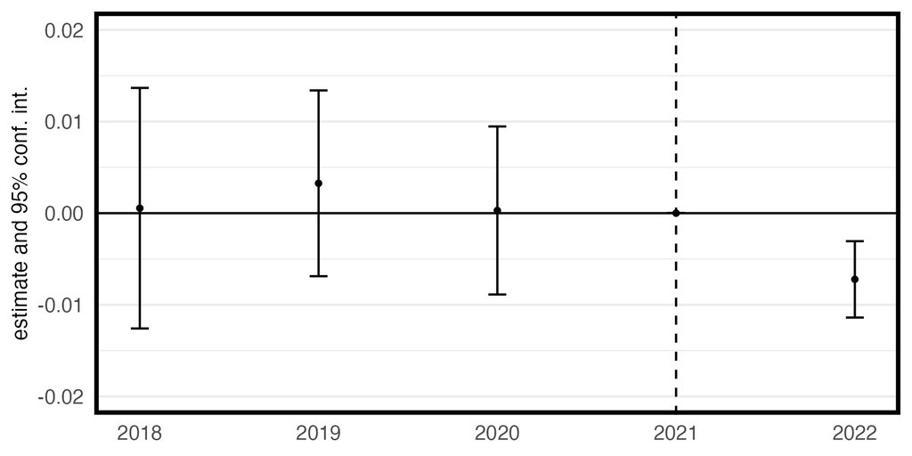

*Notes*: $0.7^{\ast\ast\ast}$ percentage point decline (Walker et al find $0.9^{\ast\ast}$)

## Effect for Schools Ranked 51+

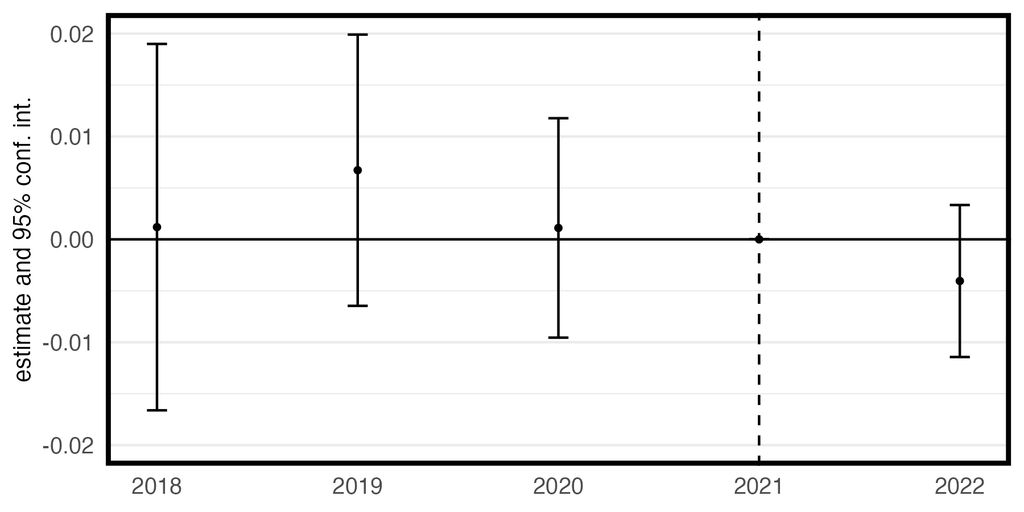

## Effect for Top 50 Schools

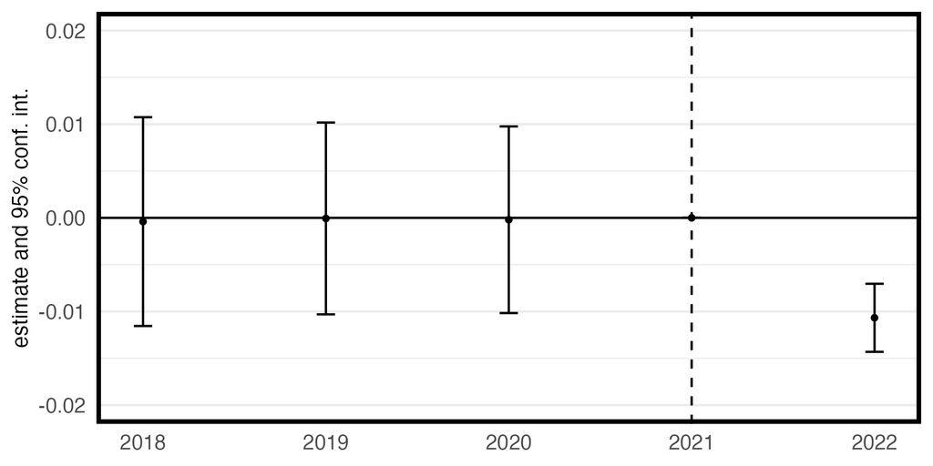

*Notes*: $1.06^{\ast\ast\ast}$ percentage point decline (Walker et al appears identical)

## Effect in Schools with 50%+ Out-of-State Freshmen

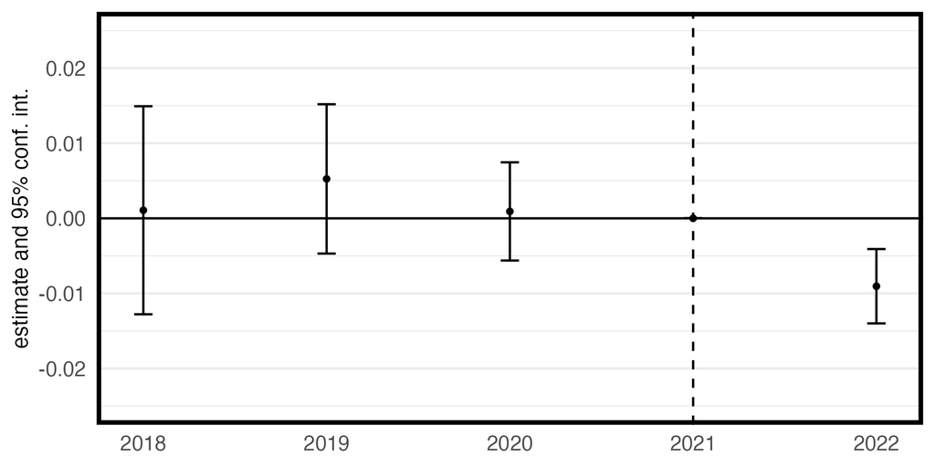

*Notes*: $0.9^{\ast\ast\ast}$ percentage point decline (Walker looks identical)

## Effect in Schools with <50% Out-of-State Freshmen

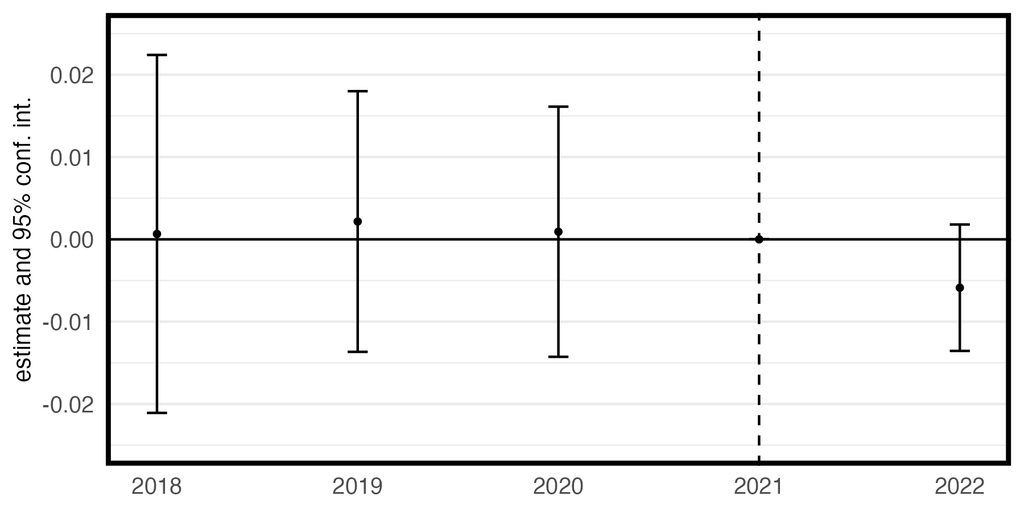

# Conclusion

- replicate Walker et al. (2023) with IPEDS data set –> slightly larger sample
- find more modest main effects but still significant decline
- limitations
  - only anticipatory effects
  - could be picking up substitution and “control” states might be affected
  - effects could be transitory
  - no time-varying covariates
- future directions
  - include time-varying covariates
  - extend data through present
    - staggered policy adoption
    - use modern estimation methods
  - use Meyer data with driving distance to nearest clinic instead of dummy

# Project, Code, Pseudocode

## Folders

generated in Terminal/Bash with `tree1`

```
├── data/
│   ├── original data/
│   │   ├── IPEDS/             # contains ADM, EF-C, HD
│   │   ├── Table 1.xlsx      # extracted from Walker
│   │   └── USNWR.xlsx        # GitHub rep
│   └── saved data/
│       └── maindf.Rdata
├── R
├── results/
│   └── figures               # saved with ggsave()
└── scripts/
    ├── analysis/
    │   └── main.R            #all analyses in one script
    ├── data processing/
    │   ├── compileIPEDS.R
    │   └── outcome-policy-variables.R
```

## Compile Data

```r
#===== COMPILE ADM DATA ====
#get list of files in folder
folder.path <- here("data","original data","IPEDS","ADM")
lf <- list.files(here(folder.path))

#initalize dataframe
ll <- 1                                   #first file in list
df <- read_csv(here(folder.path,lf[[ll]]))   #read file
yr <- lf[[ll]] |> str_extract("\\d+")     #extract year from file name

df <- df |> select(UNITID,APPLCN,APPLCNM,APPLCNW) |> mutate(year = yr[[1]],.after = UNITID)
rm(yr,ll)

#loop over remaining files
for (ll in 2:length(lf)) {
  df0 <- read_csv(here(folder.path,lf[[ll]]))
  yr <- lf[[ll]] |> str_extract("\\d+")
  df0 <- df0 |> select(UNITID,APPLCN,APPLCNM,APPLCNW) |> mutate(year = yr,.after = UNITID)
  rm(yr)
  df <- df |> bind_rows(df0)
}

df <- df |> mutate(year = as.numeric(year))
rm(df0,ll)
```

## Main Dataframe

```r
#NOTE: efc was unit x year x state but
#summarise() to unit x year (with out.percent)
hd <- hd |>
  left_join(efc,join_by(UNITID,year),relationship = "many-to-many")

df <- adm |> left_join(hd,join_by(UNITID, year))

rm(adm,hd)
```

## Example Analysis

```r
#===== FUNCTIONS =====
tidymod <- function(mod) {
  mod |> tidy(conf.int = TRUE) |>
  transmute(term = as.numeric(gsub("\\D","",term)),
            estimate,conf.low,conf.high) |>
  add_row(term =2021,estimate = 0,conf.low = 0,conf.high = 0) }


#==== MAIN RESULT ====
#run model---
mod <- feols(wshare ~ i(year,ban,ref = 2021)|UNITID+STABBR+year,
             cluster = ~STABBR,DF)

#make figure---
##myplot() passes a tidy model into ggplot() with preferred themes
mod |> tidymod() |>  myplot() +
  scale_y_continuous(limits = c(-.02,.02),breaks = seq(-.02,.02,by = .01))
```